# CM3015 MLNN - Final

### Reduce network size

Since the larger networks are still overfitting too much and will not make it to the final cut, we will remove 256 and add an 8 network. Also, we can try to taper the hidden units per layer by half for the 2nd and 3rd layer.

### Taper the hidden units per layer

```python
histories = {}
model.reset_states()
## use //2 to reduce the network of i
for i in [8, 16, 32, 64, 128]:
    model = build_model(i, i //2, i //2, 1)
    model_name = str(i) + '-' + str(i //2) + '-' + str(i //2) + '-' + str(1)
    print('Training', model_name)
    history = model.fit(partial_x_train,
                       partial_y_train,
                        epochs=20,
                        batch_size=512,
                        validation_data=(x_val, y_val),
                        verbose = 0,
                        callbacks = [CustomCallback()])
    histories[model_name] = history
    model.summary()
```

```
Training 8-4-4-1
Model: "sequential_52"
_________________________________________________________________
 Layer (type)                Output Shape              Param #
=================================================================
 dense_201 (Dense)           (None, 8)                 80008

 dropout_123 (Dropout)       (None, 8)                 0

 dense_202 (Dense)           (None, 4)                 36

 dropout_124 (Dropout)       (None, 4)                 0

 dense_203 (Dense)           (None, 4)                 20

 dropout_125 (Dropout)       (None, 4)                 0

 dense_204 (Dense)           (None, 1)                 5

=================================================================
Total params: 80069 (312.77 KB)
Trainable params: 80069 (312.77 KB)
Non-trainable params: 0 (0.00 Byte)
_________________________________________________________________
Training 16-8-8-1
Model: "sequential_53"
_________________________________________________________________
 Layer (type)                Output Shape              Param #
=================================================================
 dense_205 (Dense)           (None, 16)                160016

 dropout_126 (Dropout)       (None, 16)                0

 dense_206 (Dense)           (None, 8)                 136

 dropout_127 (Dropout)       (None, 8)                 0

 dense_207 (Dense)           (None, 8)                 72

 dropout_128 (Dropout)       (None, 8)                 0
```

[output cut: 65 more lines]

```
 dense_218 (Dense)           (None, 64)                8256

 dropout_136 (Dropout)       (None, 64)                0

 dense_219 (Dense)           (None, 64)                4160

 dropout_137 (Dropout)       (None, 64)                0

 dense_220 (Dense)           (None, 1)                 65

=================================================================
Total params: 1292609 (4.93 MB)
Trainable params: 1292609 (4.93 MB)
Non-trainable params: 0 (0.00 Byte)
_________________________________________________________________
```

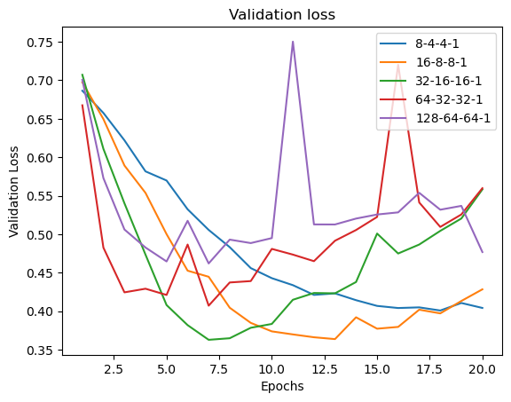

```python
#declare networks according to "histories[model_name]"
net_a, net_b, net_c, net_d, net_e = '8-4-4-1', '16-8-8-1', '32-16-16-1', '64-32-32-1', '128-64-64-1'
#plotting validation loss
plot_loss_comparison(loss_a=histories[net_a].history['val_loss'], label_a=net_a,
                     loss_b=histories[net_b].history['val_loss'], label_b=net_b,
                     loss_c=histories[net_c].history['val_loss'], label_c=net_c,
                     loss_d=histories[net_d].history['val_loss'], label_d=net_d,
                     loss_e=histories[net_e].history['val_loss'], label_e=net_e,
                        y_label='Validation Loss')
```

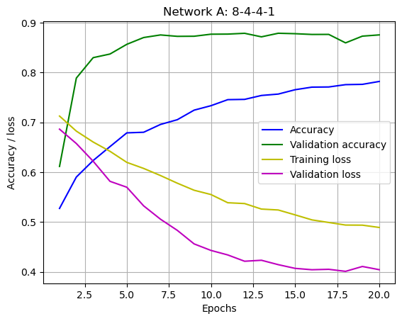

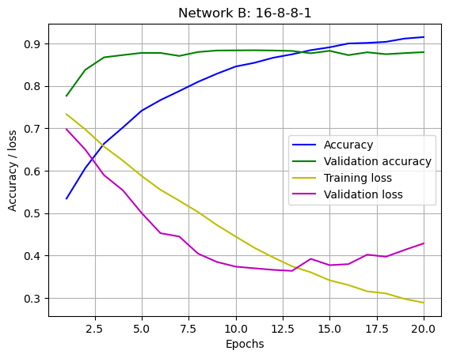

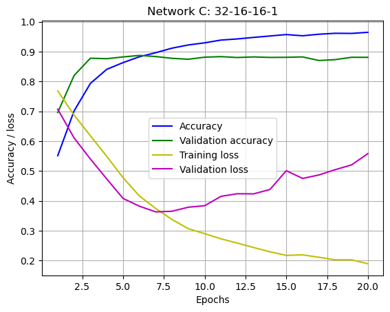

```python
# plotting training and validation accuracy as well as loss of a few interesting models
plot_net_a(acc=histories[net_a].history['accuracy'], label_a="Accuracy",
           val_acc=histories[net_a].history['val_accuracy'], label_b="Validation accuracy",
            tloss=histories[net_a].history['loss'], label_c="Training loss",
            loss=histories[net_a].history['val_loss'], label_d="Validation loss", y_label='Accuracy / loss')
plot_net_b(acc=histories[net_b].history['accuracy'], label_a="Accuracy",
           val_acc=histories[net_b].history['val_accuracy'], label_b="Validation accuracy",
            tloss=histories[net_b].history['loss'], label_c="Training loss",
            loss=histories[net_b].history['val_loss'], label_d="Validation loss", y_label='Accuracy / loss')
plot_net_c(acc=histories[net_c].history['accuracy'], label_a="Accuracy",
            val_acc=histories[net_c].history['val_accuracy'], label_b="Validation accuracy",
            tloss=histories[net_c].history['loss'], label_c="Training loss",
            loss=histories[net_c].history['val_loss'], label_d="Validation loss", y_label='Accuracy / loss')
```

**Interpretation**

Networks of interest:

- net_a (8-4-4-1)

We can see the that validation loss drops quite a bit and is actually lower than training loss. The accuracy is also quite low and it looks like this network is not powerful enough to solve our problem.

- net_b (16-8-8-1)

The training and validation loss drops together before diverging at around epoch 13. The network is still slightly overfitting. The accuracy is also not bad, but rises slowly.

- net_c (32-16-16-1)

The network is still overfitting.

### Taper more aggressively

Let’s try a batch of networks with 100% capacity for first layer, 50% capacity for second layer, and 25% capacity for third layer.

We will also increase the epochs to 50 to understand more about what is happening beyond epoch 20.

```python
histories = {}
model.reset_states()
## use //2 and //4 to reduce the network of i
for i in [8, 16, 32]:
    model = build_model(i, i //2, i //4, 1)
    model_name = str(i) + '-' + str(i //2) + '-' + str(i //4) + '-' + str(1)
    print('Training', model_name)
    history = model.fit(partial_x_train,
                       partial_y_train,
                        epochs=50,
                        batch_size=512,
                        validation_data=(x_val, y_val),
                        verbose = 0,
                        callbacks = [CustomCallback()])
    histories[model_name] = history
    model.summary()
```

```
Training 8-4-2-1
Model: "sequential_72"
_________________________________________________________________
 Layer (type)                Output Shape              Param #
=================================================================
 dense_281 (Dense)           (None, 8)                 80008

 dropout_183 (Dropout)       (None, 8)                 0

 dense_282 (Dense)           (None, 4)                 36

 dropout_184 (Dropout)       (None, 4)                 0

 dense_283 (Dense)           (None, 2)                 10

 dropout_185 (Dropout)       (None, 2)                 0

 dense_284 (Dense)           (None, 1)                 3

=================================================================
Total params: 80057 (312.72 KB)
Trainable params: 80057 (312.72 KB)
Non-trainable params: 0 (0.00 Byte)
_________________________________________________________________
Training 16-8-4-1
Model: "sequential_73"
_________________________________________________________________
 Layer (type)                Output Shape              Param #
=================================================================
 dense_285 (Dense)           (None, 16)                160016

 dropout_186 (Dropout)       (None, 16)                0

 dense_286 (Dense)           (None, 8)                 136

 dropout_187 (Dropout)       (None, 8)                 0

 dense_287 (Dense)           (None, 4)                 36

 dropout_188 (Dropout)       (None, 4)                 0
```

[output cut: 17 more lines]

```
 dense_290 (Dense)           (None, 16)                528

 dropout_190 (Dropout)       (None, 16)                0

 dense_291 (Dense)           (None, 8)                 136

 dropout_191 (Dropout)       (None, 8)                 0

 dense_292 (Dense)           (None, 1)                 9

=================================================================
Total params: 320705 (1.22 MB)
Trainable params: 320705 (1.22 MB)
Non-trainable params: 0 (0.00 Byte)
_________________________________________________________________
```

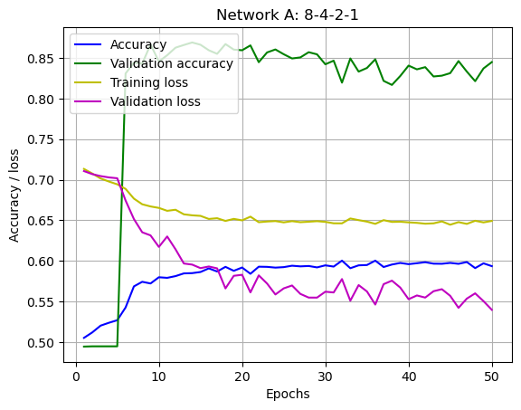

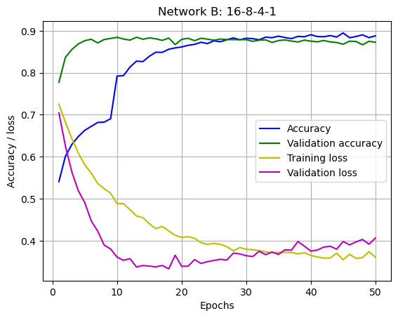

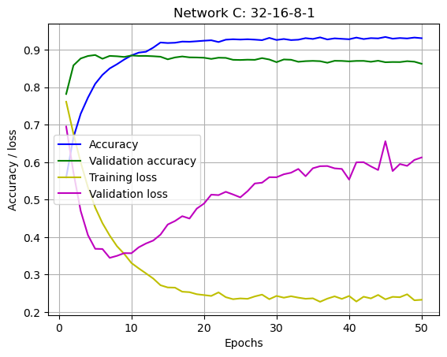

```python
#declare networks according to "histories[model_name]"
net_a, net_b, net_c = '8-4-2-1', '16-8-4-1', '32-16-8-1'

plot_net_a(acc=histories[net_a].history['accuracy'], label_a="Accuracy",
           val_acc=histories[net_a].history['val_accuracy'], label_b="Validation accuracy",
            tloss=histories[net_a].history['loss'], label_c="Training loss",
            loss=histories[net_a].history['val_loss'], label_d="Validation loss", y_label='Accuracy / loss')
plot_net_b(acc=histories[net_b].history['accuracy'], label_a="Accuracy",
           val_acc=histories[net_b].history['val_accuracy'], label_b="Validation accuracy",
            tloss=histories[net_b].history['loss'], label_c="Training loss",
            loss=histories[net_b].history['val_loss'], label_d="Validation loss", y_label='Accuracy / loss')
plot_net_c(acc=histories[net_c].history['accuracy'], label_a="Accuracy",
            val_acc=histories[net_c].history['val_accuracy'], label_b="Validation accuracy",
            tloss=histories[net_c].history['loss'], label_c="Training loss",
            loss=histories[net_c].history['val_loss'], label_d="Validation loss", y_label='Accuracy / loss')
```

**Interpretation**

Networks of interest:

- net_a (8-4-2-1)

The network is still not powerful enough

- net_b (16-8-4-1)

The validation loss drops much faster than the training loss, but then diverges at around epoch 35. Maybe it looks like it is slightly overfitting. The accuracy performance for both training and validation looks promising.

- net_c (32-16-8-1)

The network is still overfitting.